# Compare label transfer results between Azimuth and Azimuth-adapted strategy

Stephanie Spielman, Data Lab

The goal of this notebook is to compare label transfer results between:

- Label transfer code with Azimuth currently in `main` at commit `6af112d`. These results are referred to as `"azimuth"`.
- Label transfer code adapted from Azimuth at commit `3e2f90`. These results are referred to as `"adapted_azimuth"`.
- All code was run performed with the `2024-08-22` OpenScPCA data release.

## Setup

```r
knitr::opts_chunk$set(message = FALSE, warning = FALSE)
options(future.globals.maxSize = 891289600000000)

suppressPackageStartupMessages({
  library(tidyverse)
  library(patchwork)
  library(Seurat)
})

repository_base <- rprojroot::find_root(rprojroot::is_git_root)
module_base <- file.path(repository_base, "analyses", "cell-type-wilms-tumor-06")
result_dir <- file.path(module_base, "results")


# functions to perform label transfer with azimuth-adapted approach
source(
  file.path(module_base, "notebook_template", "utils", "label-transfer-functions.R")
)

# Output files
full_results_file <- file.path(module_base, "scratch", "compare-label-transfer_fetal-full.rds")
kidney_results_file <- file.path(module_base, "scratch", "compare-label-transfer_fetal-kidney.rds")
```

## Functions

```r
# Make a heatmap of counts for label transfer strategies
plot_count_heatmap <- function(df, title, sample_id) {
  all_preds <- union(df$azimuth, df$adapted_azimuth)

  plotme <- data.frame(
    azimuth = all_preds,
    adapted_azimuth = all_preds
  ) |>
    expand(azimuth, adapted_azimuth) |>
    mutate(n = NA_integer_) |>
    anti_join(distinct(df)) |>
    bind_rows(
      df |> count(azimuth, adapted_azimuth)
    ) |>
    arrange(azimuth) |>
    mutate(
      color = case_when(
        is.na(n) ~ "white",
        n <= 20 ~ "grey90",
        n <= 50 ~ "lightblue",
        n <= 100 ~ "cornflowerblue",
        n <= 500 ~ "red",
        n <= 1000 ~ "yellow2",
        .default = "yellow"
      )
    )

  ggplot(plotme) +
    aes(x = azimuth, y = adapted_azimuth, fill = color, label = n) +
    geom_tile(alpha = 0.5) +
    geom_abline(color = "firebrick", alpha = 0.5) +
    geom_text(size = 3.5) +
    # scale_fill_viridis_c(name = "count", na.value = "grey90") +
    scale_fill_identity() +
    theme_bw() +
    theme(
      axis.text.y = element_text(size = 7),
      axis.text.x = element_text(angle = 30, size = 7, hjust = 1),
      legend.position = "bottom",
      legend.title = element_text(size = 9),
      legend.text = element_text(size = 8)
    ) +
    labs(
      title = glue::glue("{sample_id}: {str_to_title(title)}")
    )
}


# Wrapper function to compare results between approaches
# Makes two plots:
# - heatmap comparing counts for cell labels between approaches
# - density plot of annotation scores for labels that agree and disagree between approaches
compare <- function(df, compare_column, score_column, title) {
  spread_df <- df |>
    select({{ compare_column }}, barcode, version) |>
    pivot_wider(names_from = version, values_from = {{ compare_column }})


  heatmap <- plot_count_heatmap(spread_df, title, unique(df$sample_id))

  disagree_barcodes <- spread_df |>
    filter(azimuth != adapted_azimuth) |>
    pull(barcode)

  df2 <- df |>
    mutate(
      agree = ifelse(barcode %in% disagree_barcodes, "labels disagree", "labels agree"),
      agree = fct_relevel(agree, "labels disagree", "labels agree")
    )

  density_plot <- ggplot(df2) +
    aes(x = {{ score_column }}, fill = agree) +
    geom_density(alpha = 0.6) +
    theme_bw() +
    ggtitle(
      glue::glue("Disagree count: {length(disagree_barcodes)} out of {nrow(spread_df)}")
    ) +
    theme(legend.position = "bottom")

  print(heatmap + density_plot + plot_layout(widths = c(2, 1)))
}
```

## Label transfer

This section both:

- Reads in existing Azimuth label transfer results
- Performs label transfer with Azimuth-adapted approach

If results are already available, we read in the files rather than regenerating results.

```r
# sample ids to process
sample_ids <- c("SCPCS000179", "SCPCS000184", "SCPCS000194", "SCPCS000205", "SCPCS000208")

# read in seurat input objects, as needed
if ((!file.exists(full_results_file)) || (!file.exists(kidney_results_file))) {
  srat_objects <- sample_ids |>
    purrr::map(
      \(id) {
        srat <- readRDS(
          file.path(result_dir, id, glue::glue("01-Seurat_{id}.Rds"))
        )
        DefaultAssay(srat) <- "RNA"

        return(srat)
      }
    )
  names(srat_objects) <- sample_ids
}
```

### Label transfer for fetal full

```r
if (!file.exists(full_results_file)) {
  # read reference
  ref <- readRDS(file.path(
    module_base,
    "results",
    "references",
    "cao_formatted_ref.rds"
  ))
  full_reference <- ref$reference
  full_refdata <- ref$refdata
  full_dims <- ref$dims
  full_annotation_columns <- c(
    glue::glue("predicted.{ref$annotation_levels}"),
    glue::glue("predicted.{ref$annotation_levels}.score")
  )


  # Perform label transfer with new code
  assay <- "RNA"
  fetal_full <- srat_objects |>
    purrr::imap(
      \(srat, id) {
        set.seed(params$seed)

        query <- prepare_query(
          srat,
          rownames(full_reference),
          assay,
          file.path(module_base, "scratch", "homologs.rds")
        )
        query <- transfer_labels(
          query,
          full_reference,
          full_dims,
          full_refdata,
          query.assay = assay
        )

        # Read in results from existing Azimuth label transfer code
        srat_02a <- readRDS(
          file.path(result_dir, id, glue::glue("02a-fetal_full_label-transfer_{id}.Rds"))
        )

        # create final data frame with all annotations
        query@meta.data[, full_annotation_columns] |>
          tibble::rownames_to_column(var = "barcode") |>
          mutate(
            sample_id = id,
            version = "adapted_azimuth"
          ) |>
          # existing results
          bind_rows(
            data.frame(
              sample_id = id,
              barcode = colnames(srat_02a),
              version = "azimuth",
              predicted.annotation.l1 = srat_02a$fetal_full_predicted.annotation.l1,
              predicted.annotation.l1.score = srat_02a$fetal_full_predicted.annotation.l1.score,
              predicted.annotation.l2 = srat_02a$fetal_full_predicted.annotation.l2,
              predicted.annotation.l2.score = srat_02a$fetal_full_predicted.annotation.l2.score,
              predicted.organ = srat_02a$fetal_full_predicted.organ,
              predicted.organ.score = srat_02a$fetal_full_predicted.organ.score
            )
          )
      }
    )
  write_rds(fetal_full, full_results_file)
} else {
  fetal_full <- read_rds(full_results_file)
}
```

### Label transfer for fetal kidney

```r
if (!file.exists(kidney_results_file)) {
  # read reference
  ref <- readRDS(file.path(
    module_base,
    "results",
    "references",
    "stewart_formatted_ref.rds"
  ))

  # Pull out information from the reference object we need for label transfer
  kidney_reference <- ref$reference
  kidney_refdata <- ref$refdata
  kidney_dims <- ref$dims
  kidney_annotation_columns <- c(
    glue::glue("predicted.{ref$annotation_levels}"),
    glue::glue("predicted.{ref$annotation_levels}.score")
  )


  # Perform label transfer with new code
  assay <- "RNA"
  fetal_kidney <- srat_objects |>
    purrr::imap(
      \(srat, id) {
        set.seed(params$seed)

        query <- prepare_query(
          srat,
          rownames(kidney_reference),
          assay,
          file.path(module_base, "scratch", "homologs.rds")
        )
        query <- transfer_labels(
          query,
          kidney_reference,
          kidney_dims,
          kidney_refdata,
          query.assay = assay
        )

        # Read in results from existing Azimuth label transfer code
        srat_02b <- readRDS(
          file.path(result_dir, id, glue::glue("02b-fetal_kidney_label-transfer_{id}.Rds"))
        )

        # create final data frame with all annotations
        query@meta.data[, kidney_annotation_columns] |>
          tibble::rownames_to_column(var = "barcode") |>
          mutate(
            sample_id = id,
            version = "adapted_azimuth"
          ) |>
          # existing results
          bind_rows(
            data.frame(
              sample_id = id,
              barcode = colnames(srat_02b),
              version = "azimuth",
              predicted.compartment = srat_02b$fetal_kidney_predicted.compartment,
              predicted.compartment.score = srat_02b$fetal_kidney_predicted.compartment.score,
              predicted.cell_type = srat_02b$fetal_kidney_predicted.cell_type,
              predicted.cell_type.score = srat_02b$fetal_kidney_predicted.cell_type.score
            )
          )
      }
    )

  write_rds(fetal_kidney, kidney_results_file)
} else {
  fetal_kidney <- read_rds(kidney_results_file)
}
```

## Compare results

We expect: - The majority of annotations match between approaches, with heatmap counts primarily falling along the diagonal - Any annotations that disagree should have low scores

### Fetal full reference

Note that results from the L2 reference are not plotted because they are not used in cell type annotation.

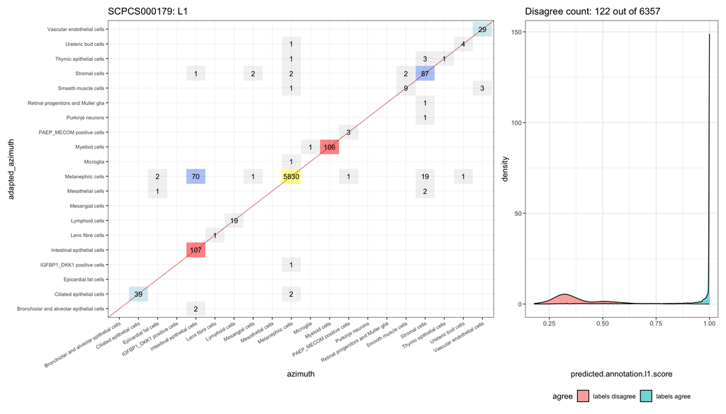

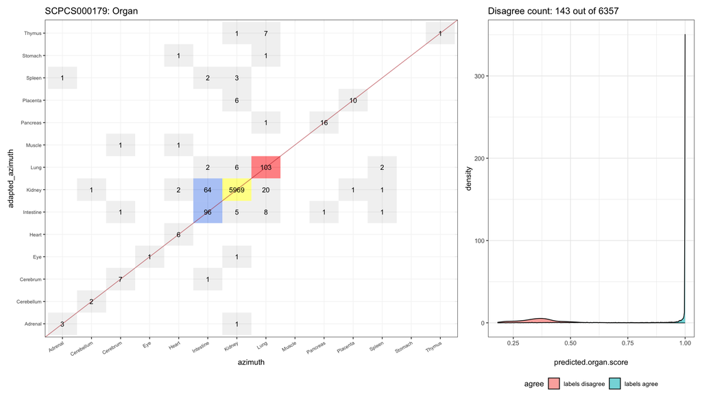

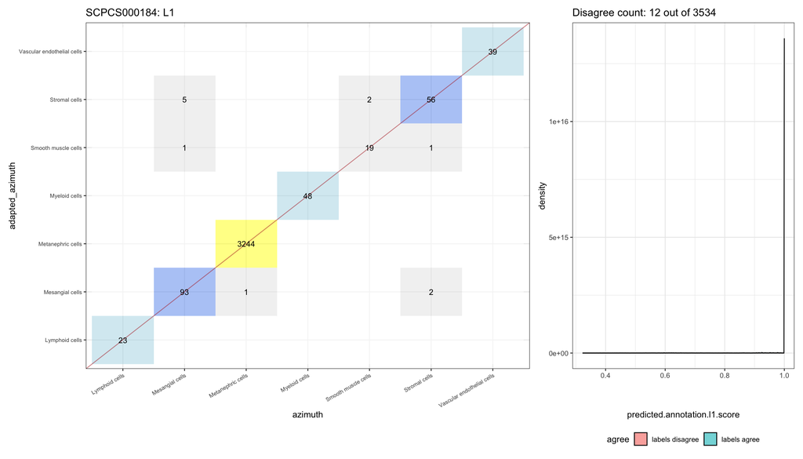

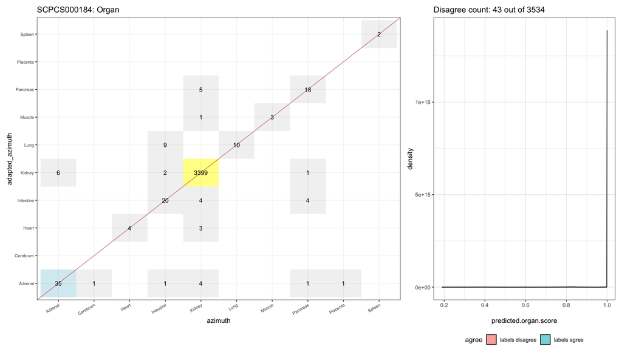

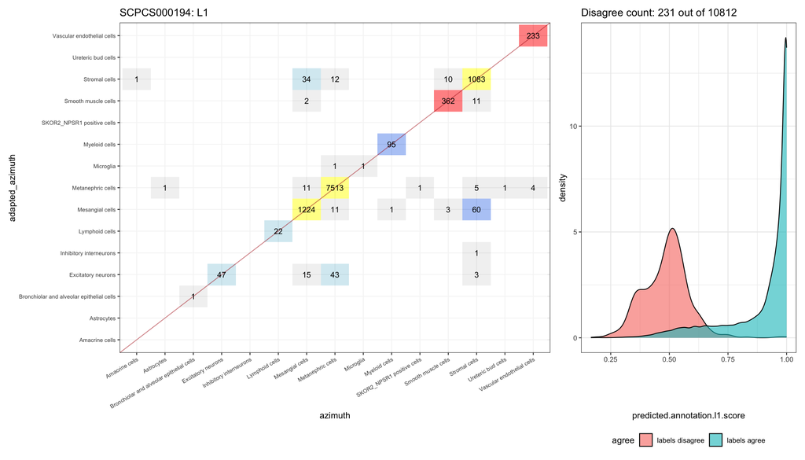

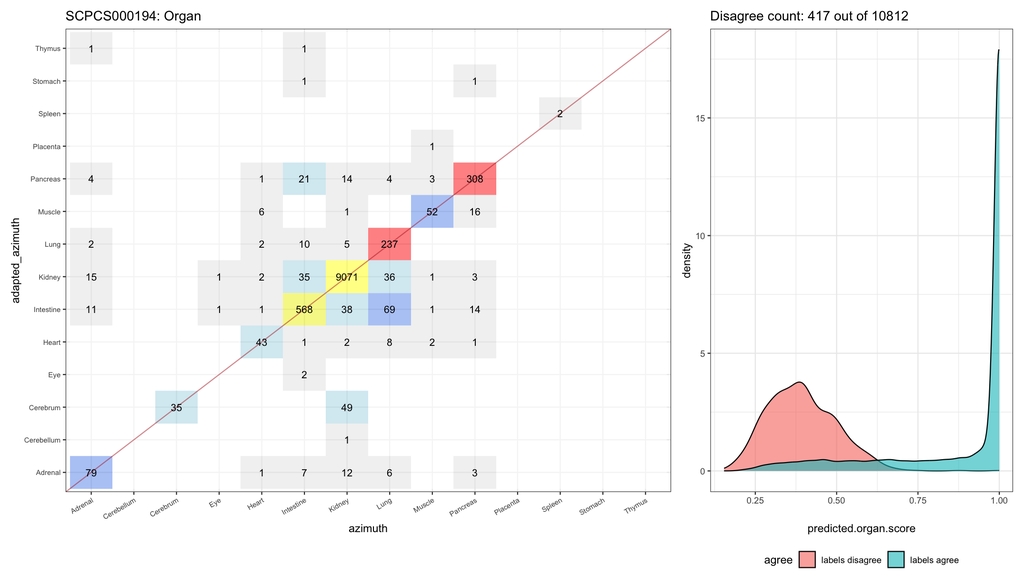

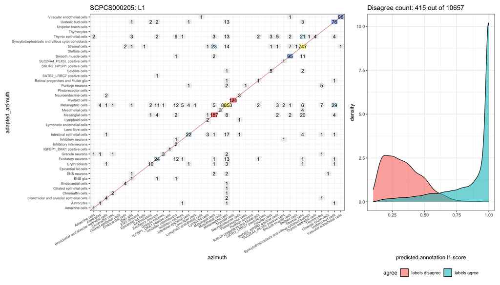

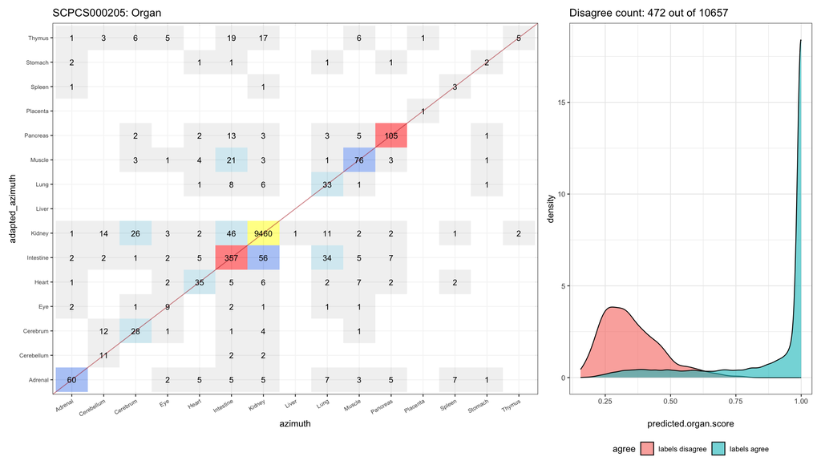

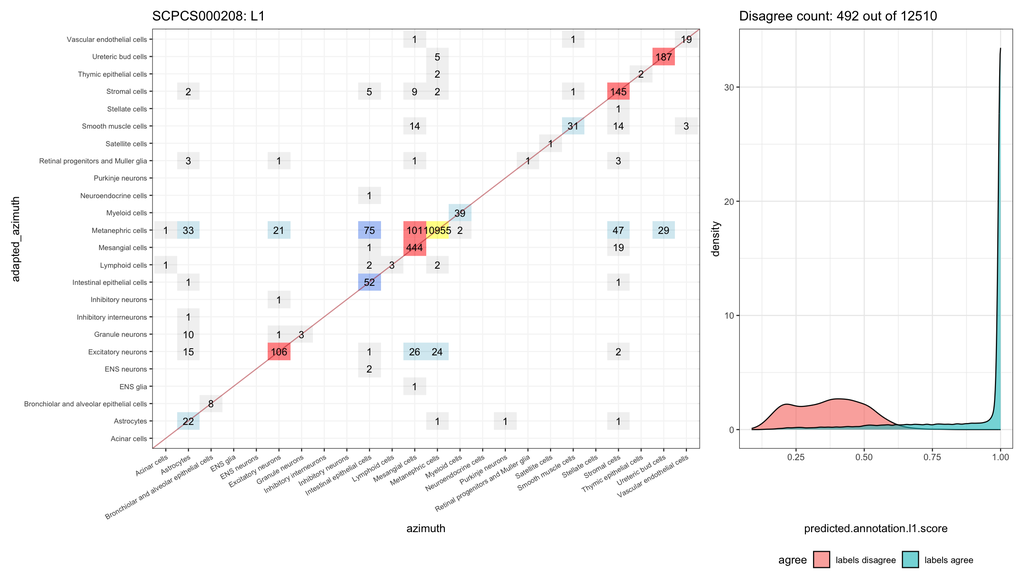

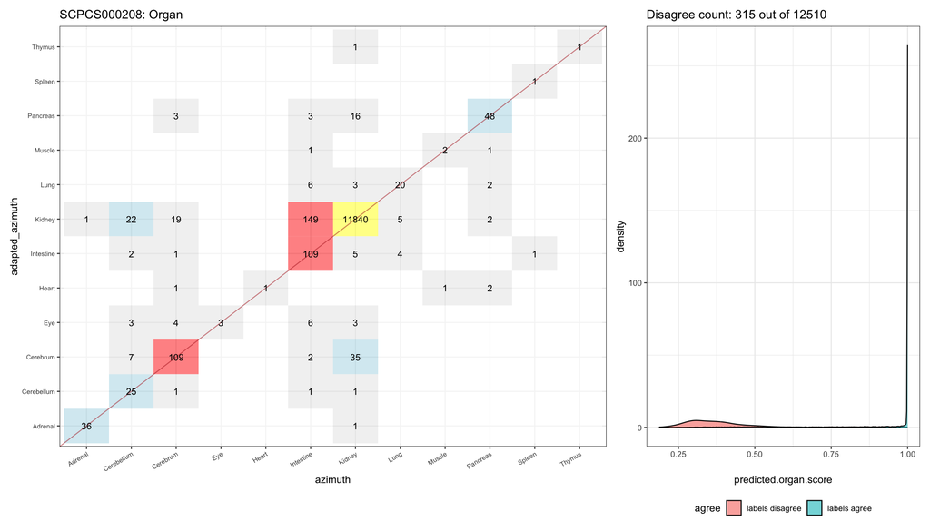

```r
fetal_full |>
  purrr::walk(
    \(dat) {
      compare(dat, predicted.annotation.l1, predicted.annotation.l1.score, "l1")
      compare(dat, predicted.organ, predicted.organ.score, "organ")
    }
  )
```

### Fetal kidney reference

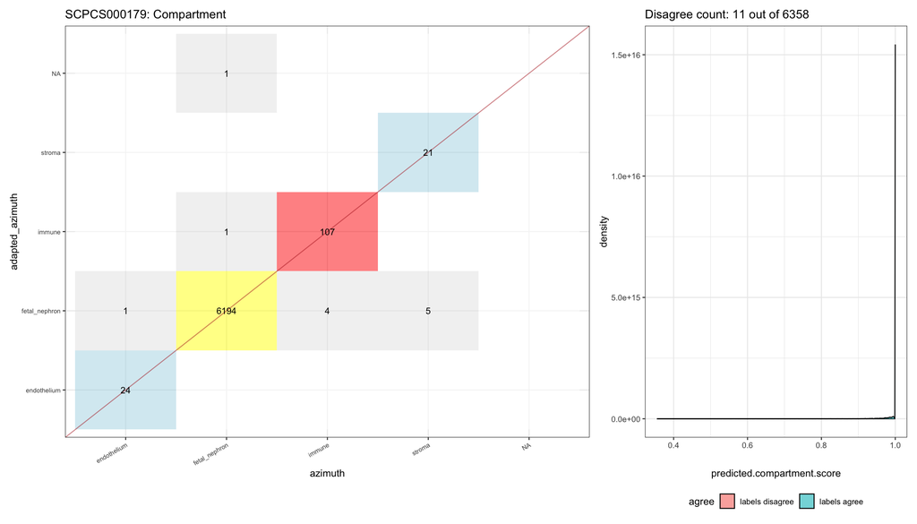

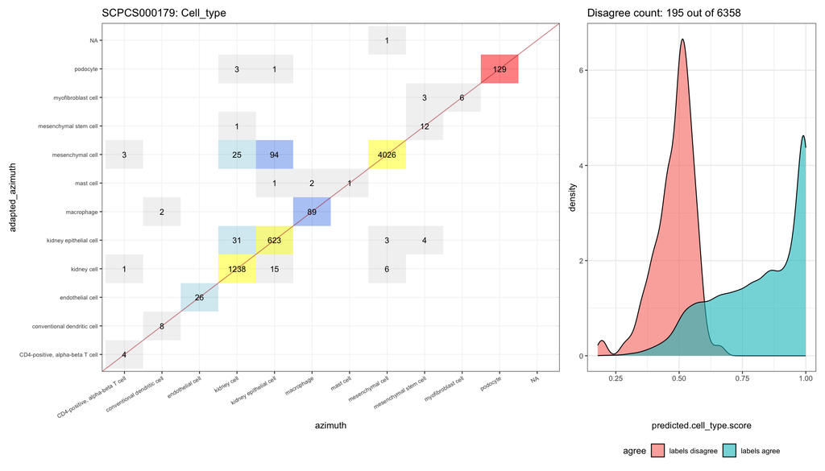

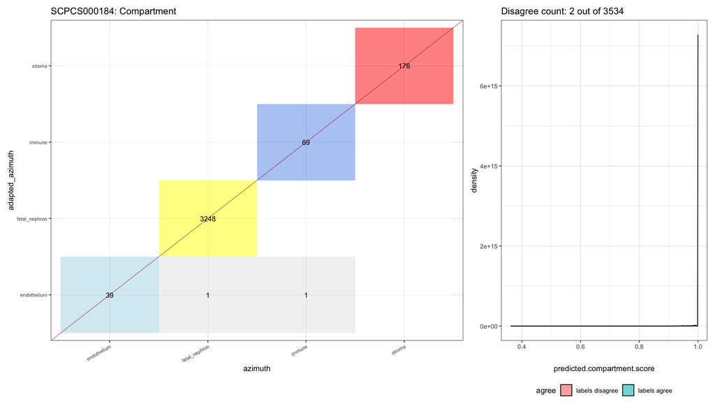

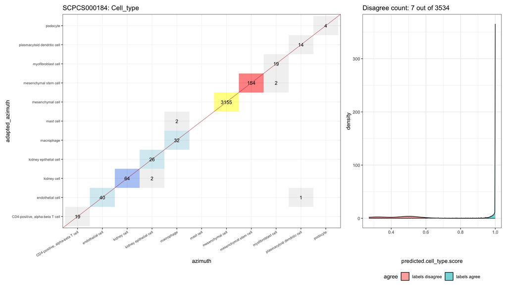

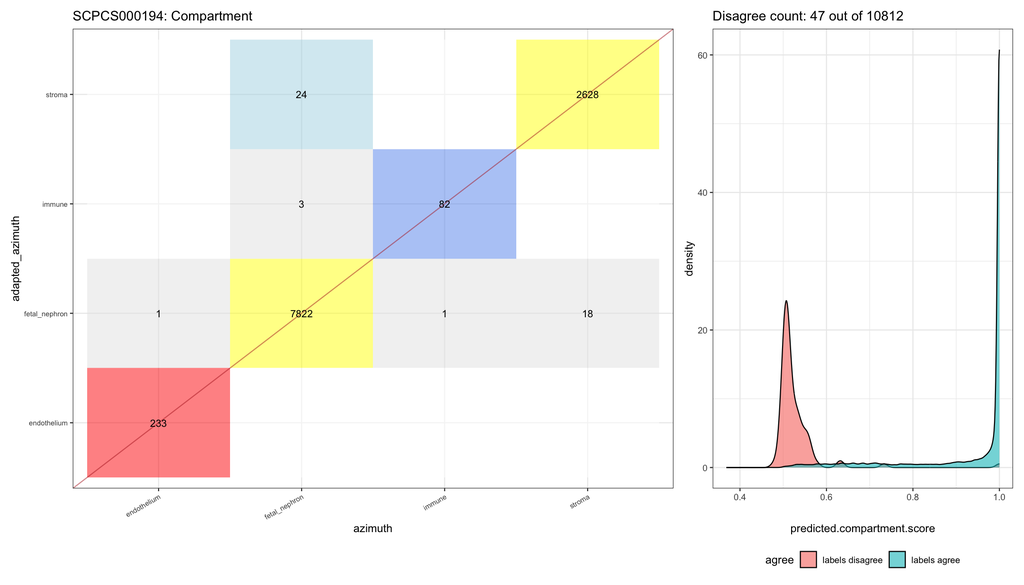

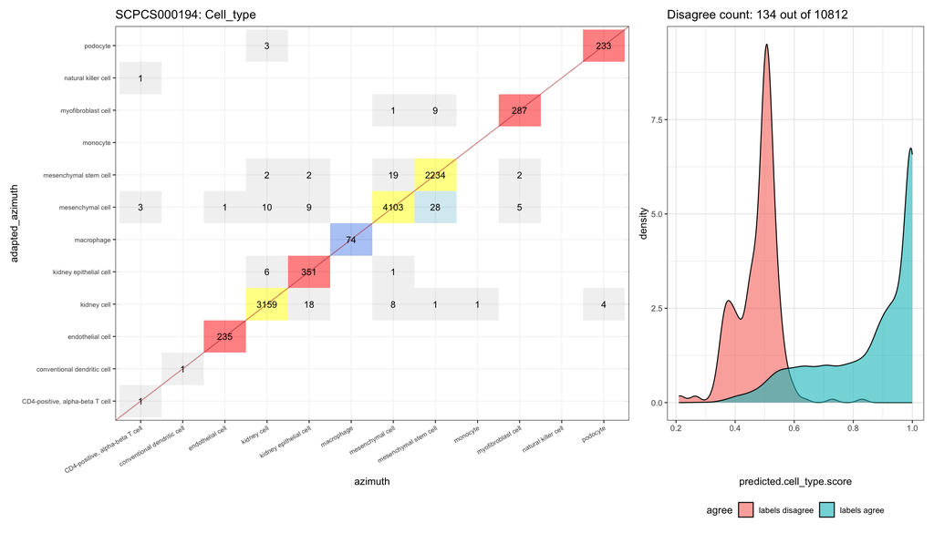

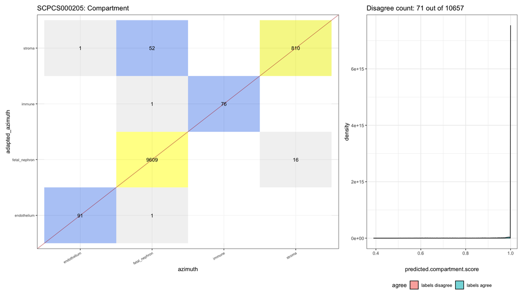

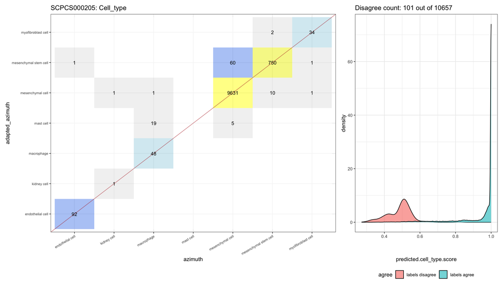

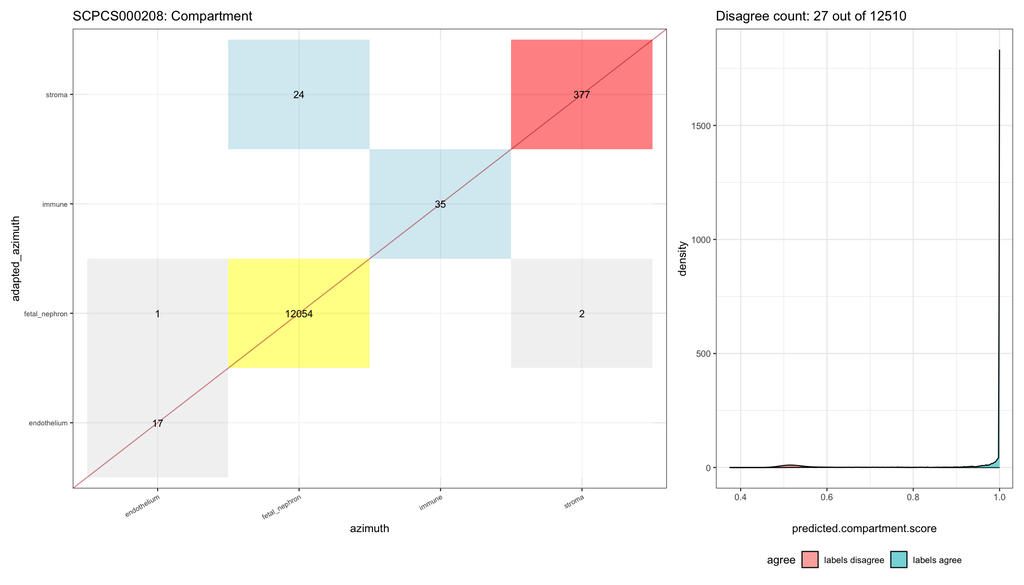

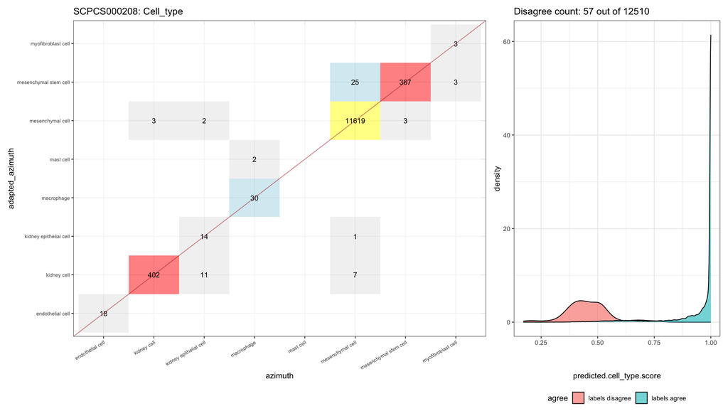

```r
fetal_kidney |>
  purrr::walk(
    \(dat) {
      compare(dat, predicted.compartment, predicted.compartment.score, "compartment")
      compare(dat, predicted.cell_type, predicted.cell_type.score, "cell_type")
    }
  )
```

## Conclusions

The vast majority of the time, labels agree. Generally speaking, when labels do not agree, their annotation scores are much lower, which is as expected.

Additional notable differences are shown in tables below:

### Fetal full reference:

[output not shown]

### Fetal kidney reference:

- Most of the cell type differences are not in the table below because they are not necessarily biologically meaningful for our purposes:
  - `kidney cell` vs `podocyte`
  - `kidney epithelial cell` vs `kidney cell`
  - `mesenchymal cell` vs `mesenchymal stem cell`

[output not shown]